# Lab 01

Rafael de Souza Guerra

8 de abril de 2019

Carregando dados:

```r
dados = read_csv("../data/series_from_imdb.csv.zip", col_types = "ccdcdcdddddddddddd")
```

Neste Lab, iremos fazer uma pequena análise exploratória sobre um dataset do IMDB contento informações sobre séries, tais como, nome da série, nome do episódio, temporada, avaliação e número de votos.

## Pergunta 1

**Quais são as 5 séries mais bem avaliadas de modo geral, considerando todos os seus episódios?**

Considerando a média como medida de avaliação, é possível responder com a seguinte consulta:

```r
dados %>% group_by(series_name) %>% summarise("Nota_media" = mean(UserRating)) %>% arrange(desc(Nota_media)) %>% top_n(5)
```

| series_name | Nota_media |
| --- | --- |
| Yeh Meri Family | 9.257143 |
| Galera do Barulho | 9.154651 |
| Game of Thrones | 9.111940 |
| Caçadores de Sombras | 9.095652 |
| Cosmos: Uma Odisséia do Espaço-Tempo | 9.076923 |

Surpreendentemente, é possível verificar que Galera do barulho, com seu último episódio indo ao ar a mais de 20 anos, mantém uma média geral superior a de séries mais recentes e populares, como Game of Thrones e Caçadores de Sombras. Vale salientar que Cosmos e Yeh Meri Family, tiveram apenas uma temporada, sendo que a última tenha uma possível continuação.

**Obs.: no restante deste lab, iremos analisar estas 5 séries citadas.**

```r
top5 = dados %>% filter(series_name %in% c("Yeh Meri Family", "Galera do Barulho", "Game of Thrones", "Caçadores de Sombras", "Cosmos: Uma Odisséia do Espaço-Tempo"))
```

## Pergunta 2

**Dentre estas séries, quantas pessoas fizeram avaliações ao todo, por série?**

```r
top5 %>% group_by(series_name) %>% summarise("Total_votos" = sum(UserVotes), "Episodios" = n(), "Votos_episodio" = mean(UserVotes)) %>% arrange(Total_votos)
```

| series_name | Total_votos | Episodios | Votos_episodio |
| --- | --- | --- | --- |
| Yeh Meri Family | 1586 | 7 | 226.5714 |
| Cosmos: Uma Odisséia do Espaço-Tempo | 18905 | 13 | 1454.2308 |
| Galera do Barulho | 22287 | 86 | 259.1512 |
| Caçadores de Sombras | 95407 | 46 | 2074.0652 |
| Game of Thrones | 1960220 | 67 | 29257.0149 |

Aqui verificamos que, apesar de possuir a maior nota média de todas as séries do IMDB, Yeh Meri Family possui um número de votantes muito menor que Game of Thrones. Também podemos ver que, apesar de Cosmos ter menos avaliações que Galera do Barulho, possui uma maior média de votos por episódio.

## Pergunta 3

**Dentre estas séries, como as avaliações se comportam no decorrer dos episódios? Existe alguma tendência?**

Para fins de organização e detalhes, essa pergunta será respondida por meio de vários graficos:

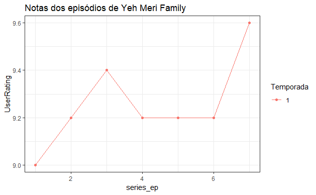

```r
top5 %>% filter(series_name == "Yeh Meri Family") %>% ggplot() + geom_line(mapping = aes(x = series_ep, y = UserRating, color = as.character(season))) + geom_point(mapping = aes(x = series_ep, y = UserRating, color = season)) + labs(title = "Notas dos episódios de Yeh Meri Family", color = "Temporada")
```

Aqui podemos observar que a série, no geral, se manteve num crescimento relativamente estável, com o último episódio obtendo notas maiores que o primeiro.

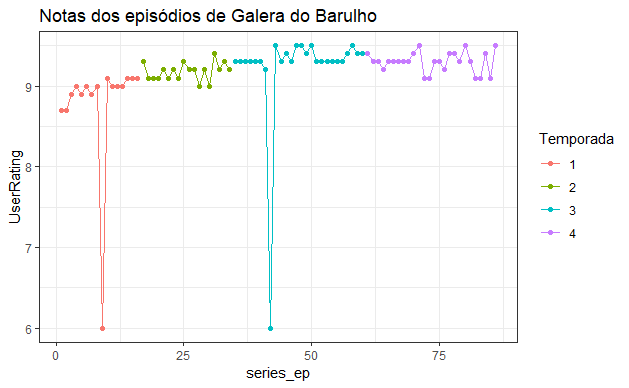

```r
top5 %>% filter(series_name == "Galera do Barulho") %>% ggplot() + geom_line(mapping = aes(x = series_ep, y = UserRating, color = as.character(season))) + geom_point(mapping = aes(x = series_ep, y = UserRating, color = season)) + labs(title = "Notas dos episódios de Galera do Barulho", color = "Temporada")
```

Em Galera do Barulho, podemos observar que a série se manteve bem estável, com um leve crescimento nas avaliações. É importante observar que houveram dois episódios bem abaixo da média da série.

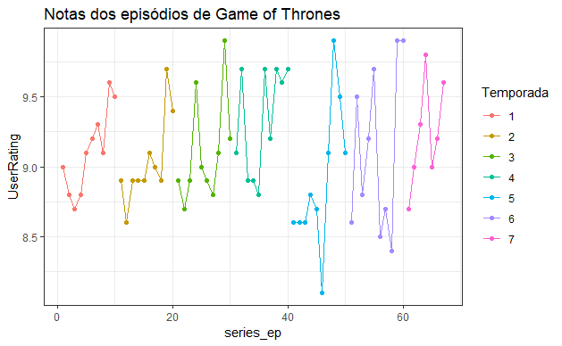

```r
top5 %>% filter(series_name == "Game of Thrones") %>% ggplot() + geom_line(mapping = aes(x = series_ep, y = UserRating, color = as.character(season))) + geom_point(mapping = aes(x = series_ep, y = UserRating, color = season)) + labs(title = "Notas dos episódios de Game of Thrones", color = "Temporada")
```

Em Game of Thrones, a variação das avaliações não nos permite identificar uma tendência, mas é possível identificar a diferença entre a pior avaliação com nota um pouco maior que 8 e as quatro maiores avaliações, que quase atingiram nota 10

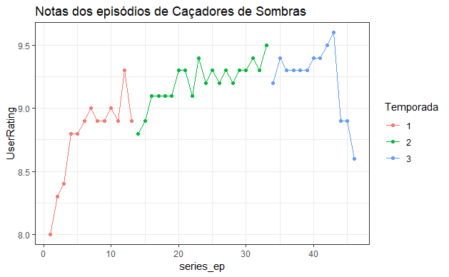

```r
top5 %>% filter(series_name == "Caçadores de Sombras") %>% ggplot() + geom_line(mapping = aes(x = series_ep, y = UserRating, color = as.character(season))) + geom_point(mapping = aes(x = series_ep, y = UserRating, color = season)) + labs(title = "Notas dos episódios de Caçadores de Sombras", color = "Temporada")
```

Em Caçadores de Sombras, é possível identificar um enorme avanço no decorrer da série, mas que na sua última temporada, obteve uma drástica queda.

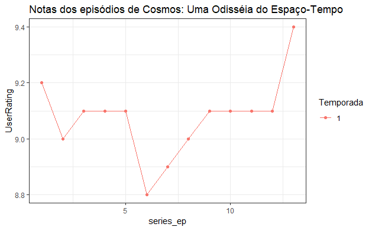

```r
top5 %>% filter(series_name == "Cosmos: Uma Odisséia do Espaço-Tempo") %>% ggplot() + geom_line(mapping = aes(x = series_ep, y = UserRating, color = as.character(season))) + geom_point(mapping = aes(x = series_ep, y = UserRating, color = season)) + labs(title = "Notas dos episódios de Cosmos: Uma Odisséia do Espaço-Tempo", color = "Temporada")
```

Em Cosmos: Uma Odisséia do Espaço-Tempo, é possível verificar que a série sofreu um declínio no meio da temporada, mas conseguiu se redimir e fechou seu episódio final com nota superior à do primeiro.

## Pergunta 4

**Há alguma relação entre as notas obtidas nos episódios e o numero de pessoas que os avaliaram?**

Tomando, por exemplo, a série Game of Thrones:

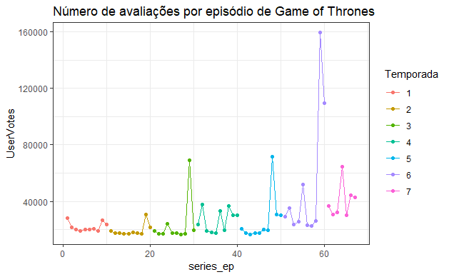

```r
top5 %>% filter(series_name == "Game of Thrones") %>% ggplot() + geom_line(mapping = aes(x = series_ep, y = UserVotes, color = as.character(season))) + geom_point(mapping = aes(x = series_ep, y = UserVotes, color = season)) + labs(title = "Número de avaliações por episódio de Game of Thrones", color = "Temporada")
```

Aqui podemos identificar que uma certa relação entre a nota obtida pelo episódio e o número de votantes. O sexto episódio da quinta temporada foi o mais criticado e obteve cerca de vinte mil avaliações. Já o nono episódio da sexta temporada obteve grande número de votantes e uma das mais altas avaliações e o caso se repete para outros episódios, como o nono episódio da terceira temporada e o oitavo da quinta, embora com menor número de votantes.